# Résultats du pool de saison régulière 2025

**Tip**

“*Luck favours the brave and the well prepared.*”

- Mike

# Points réels versus optimaux

> Le graphique suivant présente les points réels effectués tout au long de la saison en bleu et les points optimaux en rouge. Les points optimaux laissent votre pire joueur par position sur le banc selon chaque semaine. Le pourcentage représente l’efficacité.

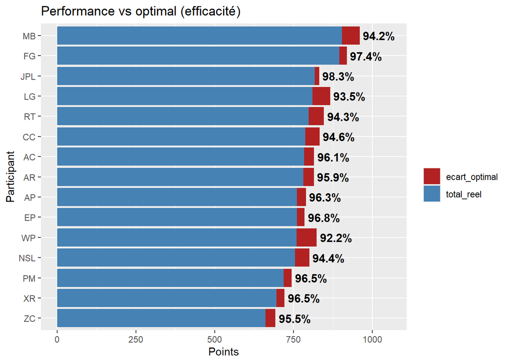

Conclusions:

1. Lorélie aurait pu atteindre le top 3 et cash out si elle avait géré ses bancs comme du monde.
2. Mariève a tellement “assert dominance” qu’elle a mal gérée son banc tout en restant première.
3. William est le pire gestionnaire de son banc.

# Points par semaine

> Les semaines 19 et 20 sont nulles à cause des olympiques.

[interactive chart not shown]

```
[1] "Félicitations à MB qui a eu 53 points lors de la semaine 4."
```

```
[1] "Mention non honorable à RT qui a eu 11 points lors de la semaine 12."
```

# Points cumulés

[interactive chart not shown]

```
[1] "MB a assert sa dominance dans 100% des périodes!"
```

Il y a eu peu de changements du classement au fil de la saison, il semble y avoir 3 catégories claires: les participants talentueux (MB et FG), le monde mid et ceux qui conaissent vraiment rien au hockey (PM, XR et ZC)

# Comparaison du projeté et de l’optimal par position

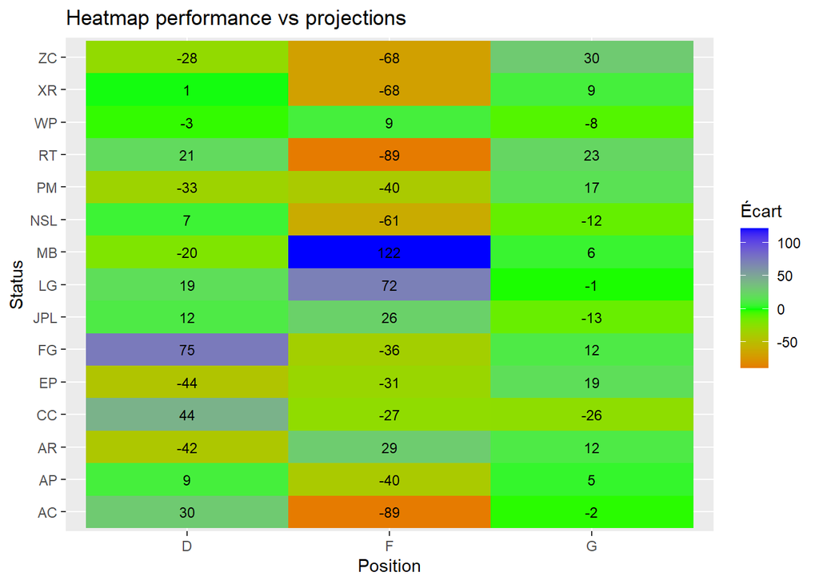

Les attaquants optimisés de Mariève ont fait 122 points de plus que selon le projeté!